# 北京市二手房价格预测分析

### 房屋面积分布

```r
quantile(dat$AREA) #从数据可以看出，有异常值出现，不太符合现实情况
```

```
##       0%      25%      50%      75%     100%
##     7.80    60.00    78.80   111.76 18779.50
```

```r
##       0%      25%      50%      75%     100%
##     7.80    60.00    78.80   111.76 18779.50
```

```r
quantile(dat$AREA, probs = c(0.01,0.99)) #查看1%和99%的分位数
```

```
##       1%      99%
##  33.9825 284.9775
```

```r
##       1%      99%
##  33.9825 284.9775
```

```r
dat <- dat[dat$AREA>34 & dat$AREA<300, ] #删除房屋面积小于30或者大于300平米的观测值
```

### 房价分布

```r
quantile(dat$price) #有许多异常值
```

```
##        0%       25%       50%       75%      100%
##  18348.00  42771.25  57376.50  75958.25 182223.00
```

```r
##        0%       25%       50%       75%      100%
##  18348.00  42771.25  57376.50  75958.25 182223.00
```

```r
quantile(dat$price, probs = c(0.001,0.999)) #查看0.1%和99.9%的分位数
```

```
##     0.1%    99.9%
##  21569.1 144945.4
```

```r
##     0.1%    99.9%
##  21569.1 144945.4
```

```r
dat <- dat[dat$price>21000 & dat$price<150000, ]
```

### 北京经纬度取值范围

```r
dat <- dat[dat$LONG>=115.5 & dat$LONG <= 117.5, ] #经度115.5~117.5
dat <- dat[dat$LAT>=39.5 & dat$LAT <= 41, ] #纬度39.5~41
```

### 是否临近地铁

```r
prop.table(table(dat$subway)) #82.8%的观测临近地铁
```

```
##
##         0         1
## 0.1720976 0.8279024
```

```r
##         0         1
## 0.1720976 0.8279024
```

### 是否为学区房

```r
prop.table(table(dat$school)) #30.4%的观测是学区房
```

```
##
##         0         1
## 0.6961343 0.3038657
```

```r
##         0         1
## 0.6961343 0.3038657
```

### 保存清洗后的数据

```r
write.csv(dat, file='mydata.csv',row.names = F)
```

## 描述性分析

### 数据导入

```r
dat <- read.csv('mydata.csv', header = T)
str(dat)
```

```
## 'data.frame':    16142 obs. of  12 variables:
##  $ CATE    : Factor w/ 6 levels "chaoyang","dongcheng",..: 1 1 4 4 3 3 4 4 4 3 ...
##  $ bedrooms: int  1 1 5 3 2 2 2 2 2 2 ...
##  $ halls   : int  0 1 2 2 1 1 1 1 1 2 ...
##  $ AREA    : num  46.1 59.1 278.9 207 53.3 ...
##  $ floor   : Factor w/ 3 levels "high","low","middle": 3 3 1 1 2 2 2 3 3 3 ...
##  $ subway  : int  1 1 1 1 1 1 1 1 1 1 ...
##  $ school  : int  0 0 1 1 1 1 1 1 1 0 ...
##  $ price   : int  48850 46540 71662 57972 71268 70690 57348 55179 45591 73585 ...
##  $ LONG    : num  116 116 116 116 116 ...
##  $ LAT     : num  39.9 39.9 40 40 39.9 ...
##  $ NAME    : Factor w/ 2951 levels "10AM新坐标","10号名邸",..: 1 1 2 2 3 3 4 4 4 5 ...
##  $ DISTRICT: Factor w/ 173 levels "CBD","安定门",..: 41 41 172 172 95 95 98 98 98 84 ...
```

```r
## 'data.frame':    16142 obs. of  12 variables:
##  $ CATE    : Factor w/ 6 levels "chaoyang","dongcheng",.: 1 1 4 4 3 3 4 4 4 3 ..
##  $ bedrooms: int  1 1 5 3 2 2 2 2 2 2 ..
##  $ halls   : int  0 1 2 2 1 1 1 1 1 2 ..
##  $ AREA    : num  46.1 59.1 278.9 207 53.3 ..
##  $ floor   : Factor w/ 3 levels "high","low","middle": 3 3 1 1 2 2 2 3 3 3 ..
##  $ subway  : int  1 1 1 1 1 1 1 1 1 1 ..
##  $ school  : int  0 0 1 1 1 1 1 1 1 0 ..
##  $ price   : int  48850 46540 71662 57972 71268 70690 57348 55179 45591 73585 ..
##  $ LONG    : num  116 116 116 116 116 ..
##  $ LAT     : num  39.9 39.9 40 40 39.9 ..
##  $ NAME    : Factor w/ 2951 levels "10AM新坐标","10号名邸",.: 1 1 2 2 3 3 4 4 4 5 ..
##  $ DISTRICT: Factor w/ 173 levels "CBD","安定门",.: 45 45 172 172 99 99 103 103 103 88 ..
```

```r
head(dat)
```

```
##       CATE bedrooms halls   AREA  floor subway school price     LONG
## 1 chaoyang        1     0  46.06 middle      1      0 48850 116.4597
## 2 chaoyang        1     1  59.09 middle      1      0 46540 116.4597
## 3  haidian        5     2 278.95   high      1      1 71662 116.3036
## 4  haidian        3     2 207.00   high      1      1 57972 116.3036
## 5  fengtai        2     1  53.32    low      1      1 71268 116.4188
## 6  fengtai        2     1  58.00    low      1      1 70690 116.4188
##        LAT       NAME DISTRICT
## 1 39.92835 10AM新坐标     方庄
## 2 39.92835 10AM新坐标     方庄
## 3 39.95481   10号名邸   紫竹桥
## 4 39.95481   10号名邸   紫竹桥
## 5 39.94381   17号旁门   蒲黄榆
## 6 39.94381   17号旁门   蒲黄榆
```

```r
##       CATE bedrooms halls   AREA  floor subway school price     LONG
## 1 chaoyang        1     0  46.06 middle      1      0 48850 116.4597
## 2 chaoyang        1     1  59.09 middle      1      0 46540 116.4597
## 3  haidian        5     2 278.95   high      1      1 71662 116.3036
## 4  haidian        3     2 207.00   high      1      1 57972 116.3036
## 5  fengtai        2     1  53.32    low      1      1 71268 116.4188
## 6  fengtai        2     1  58.00    low      1      1 70690 116.4188
##        LAT       NAME DISTRICT
## 1 39.92835 10AM新坐标     方庄
## 2 39.92835 10AM新坐标     方庄
## 3 39.95481   10号名邸   紫竹桥
## 4 39.95481   10号名邸   紫竹桥
## 5 39.94381   17号旁门   蒲黄榆
## 6 39.94381   17号旁门   蒲黄榆
```

```r
#将bedrooms,halls,subway和school字段转化为因子类型数据
dat[, c(2,3,6,7)] <- as.data.frame(apply(dat[, c(2,3,6,7)], 2, as.factor))
summary(dat)
```

```
##           CATE      bedrooms halls          AREA           floor
##  chaoyang   :2864   1:3154   0:  788   Min.   : 34.02   high  :5529
##  dongcheng  :2768   2:7963   1:11040   1st Qu.: 60.20   low   :5058
##  fengtai    :2938   3:4249   2: 4229   Median : 79.00   middle:5555
##  haidian    :2917   4: 674   3:   85   Mean   : 91.96
##  shijingshan:1936   5: 102             3rd Qu.:110.81
##  xicheng    :2719                      Max.   :299.00
##
##  subway    school        price             LONG            LAT
##  0: 2778   0:11237   Min.   : 21053   Min.   :116.0   Min.   :39.66
##  1:13364   1: 4905   1st Qu.: 42817   1st Qu.:116.3   1st Qu.:39.89
##                      Median : 57422   Median :116.4   Median :39.92
##                      Mean   : 61118   Mean   :116.4   Mean   :39.93
##                      3rd Qu.: 76010   3rd Qu.:116.4   3rd Qu.:39.96
##                      Max.   :149871   Max.   :117.1   Max.   :40.48
##
##            NAME          DISTRICT
##  远洋山水    :  187   鲁谷   :  916
##  裕中西里    :  104   马甸   :  418
##  裕中东里    :   94   望京   :  409
##  永乐东区    :   81   苹果园 :  400
##  海特花园小区:   73   广渠门 :  365
##  新景家园东区:   62   崇文门 :  315
##  (Other)     :15541   (Other):13319
```

```r
##           CATE      bedrooms halls          AREA           floor
##  chaoyang   :2864   1:3154   0:  788   Min.   : 34.02   high  :5529
##  dongcheng  :2768   2:7963   1:11040   1st Qu.: 60.20   low   :5058
##  fengtai    :2938   3:4249   2: 4229   Median : 79.00   middle:5555
##  haidian    :2917   4: 674   3:   85   Mean   : 91.96
##  shijingshan:1936   5: 102             3rd Qu.:110.81
##  xicheng    :2719                      Max.   :299.00
##
##  subway    school        price             LONG            LAT
##  0: 2778   0:11237   Min.   : 21053   Min.   :116.0   Min.   :39.66
##  1:13364   1: 4905   1st Qu.: 42817   1st Qu.:116.3   1st Qu.:39.89
##                      Median : 57422   Median :116.4   Median :39.92
##                      Mean   : 61118   Mean   :116.4   Mean   :39.93
##                      3rd Qu.: 76010   3rd Qu.:116.4   3rd Qu.:39.96
##                      Max.   :149871   Max.   :117.1   Max.   :40.48
##
##            NAME          DISTRICT
##  远洋山水    :  187   鲁谷   :  916
##  裕中西里    :  104   马甸   :  418
##  裕中东里    :   94   望京   :  409
##  永乐东区    :   81   苹果园 :  400
##  海特花园小区:   73   广渠门 :  365
##  新景家园东区:   62   崇文门 :  315
##  (Other)     :15541   (Other):13319
```

在分析之前，将CATE和floor字段的取值换成中文，以便作图输出美观

```r
dict1 <- levels(dat$CATE)
dict2 <- c('朝阳','东城','丰台','海淀','石景山','西城')
dat$CATE <- as.factor(dict2[match(dat$CATE, dict1)])

dict3 <- levels(dat$floor)
dict4 <- c('高','低','中')
dat$floor <- as.factor(dict4[match(dat$floor, dict3)])
```

### 北京市场二手房房价分布图

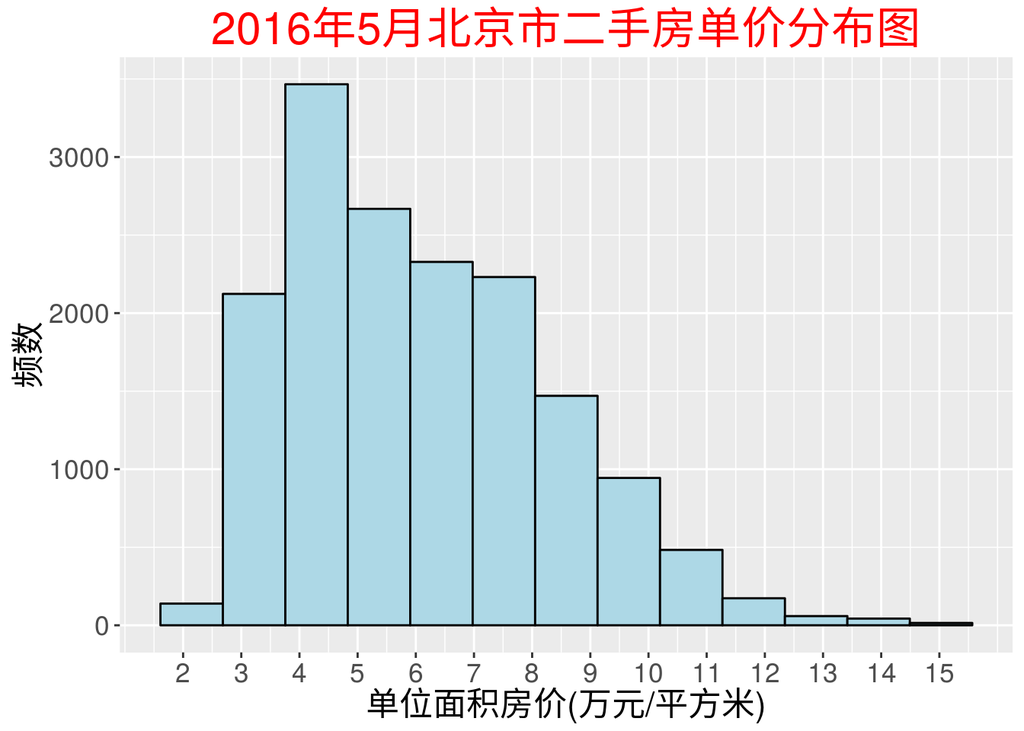

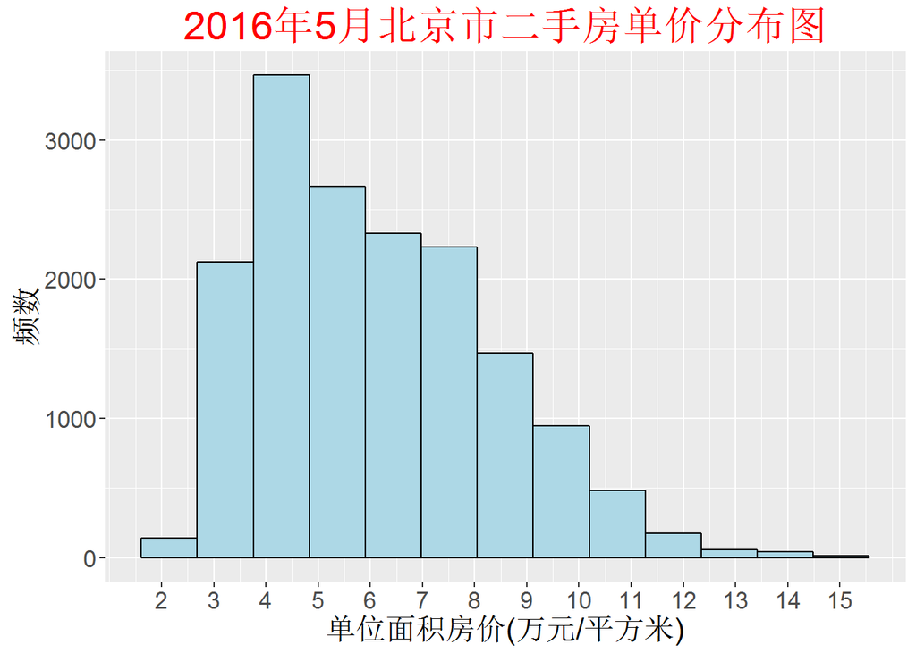

p1

```r
dat$price <- dat$price/10000  #单位转化为万元
library(ggplot2)
ggplot(dat, aes(x=price)) +
  geom_histogram(bins=13, fill='lightblue', color='black') +
  theme(axis.text.x=element_text(size=rel(1.5)), axis.text.y=element_text(size=rel(1.5)),
        axis.title.x=element_text(size=rel(1.5)), axis.title.y=element_text(size=rel(1.5)),
        plot.title=element_text(size=rel(2), color='red')) +
  labs(x='单位面积房价(万元/平方米)', y='频数', title='2016年5月北京市二手房单价分布图') +
  scale_x_continuous(breaks=c(2:15))
```

```r
dat[which.max(dat$price), ] #求出房价最高的观测值
```

```
##       CATE bedrooms halls AREA floor subway school   price    LONG     LAT
## 12730 西城        3     1 77.4    低      1      0 14.9871 116.375 39.9099
##           NAME DISTRICT
## 12730 新文化街   金融街
```

```r
dat[which.min(dat$price), ] #求出房价最低的观测值
```

```
##       CATE bedrooms halls AREA floor subway school  price     LONG
## 12351 丰台        4     2  171    高      0      0 2.1053 116.2481
##            LAT       NAME DISTRICT
## 12351 39.84295 晓月苑三里   卢沟桥
```

```r
##       CATE bedrooms halls AREA floor subway school  price     LONG
## 12351 丰台        4     2  171    高      0      0 2.1053 116.2481
##            LAT       NAME DISTRICT
## 12351 39.84295 晓月苑三里   卢沟桥
```

### 六大城区对房价的分组箱线图

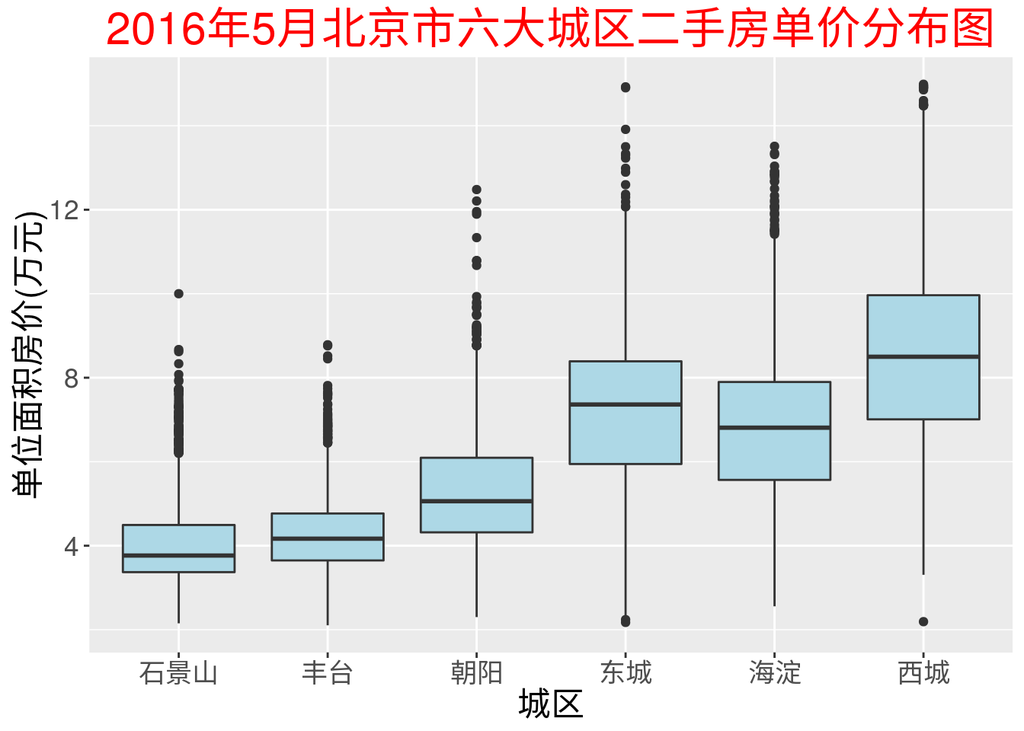

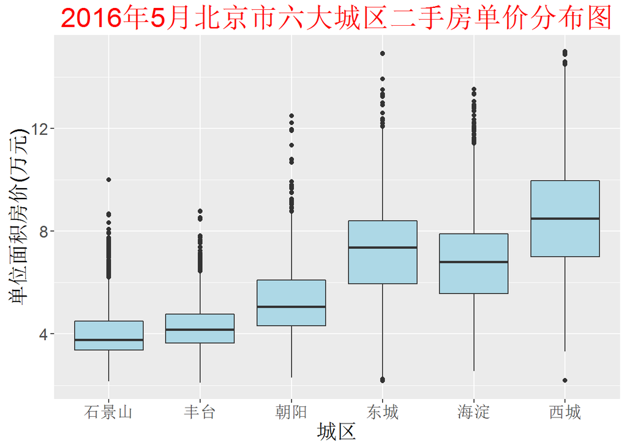

p2

```r
ggplot(dat, aes(x=CATE,y=price)) +
  geom_boxplot(fill='lightblue') +
  theme(axis.text.x=element_text(size=rel(1.5)), axis.text.y=element_text(size=rel(1.5)),
        axis.title.x=element_text(size=rel(1.5)), axis.title.y=element_text(size=rel(1.5)),
        plot.title=element_text(size=rel(2), color='red')) +
  labs(x='城区', y='单位面积房价(万元)', title='2016年5月北京市六大城区二手房单价分布图') +
  scale_x_discrete(limits=c('石景山','丰台','朝阳','东城','海淀','西城'))
```

由图可知，六大城区的二手房单价大致可以分为两组：

- 第一组为石景山、丰台、朝阳，单价相差不多，朝阳相对来说高单价的会更多些。
- 第二组为东城、海淀、西城，组内单价相差不大，但相对第一组来说单价高了很多。

### 卧室数对房价的分组箱线图

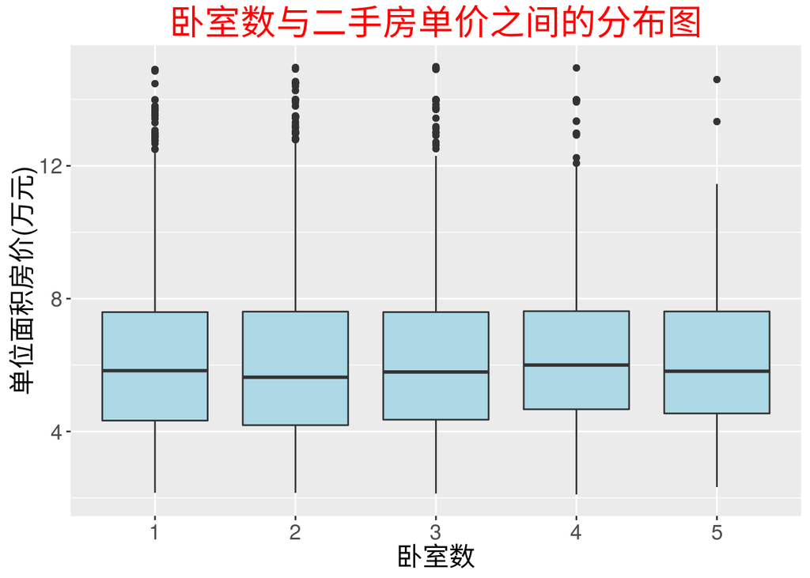

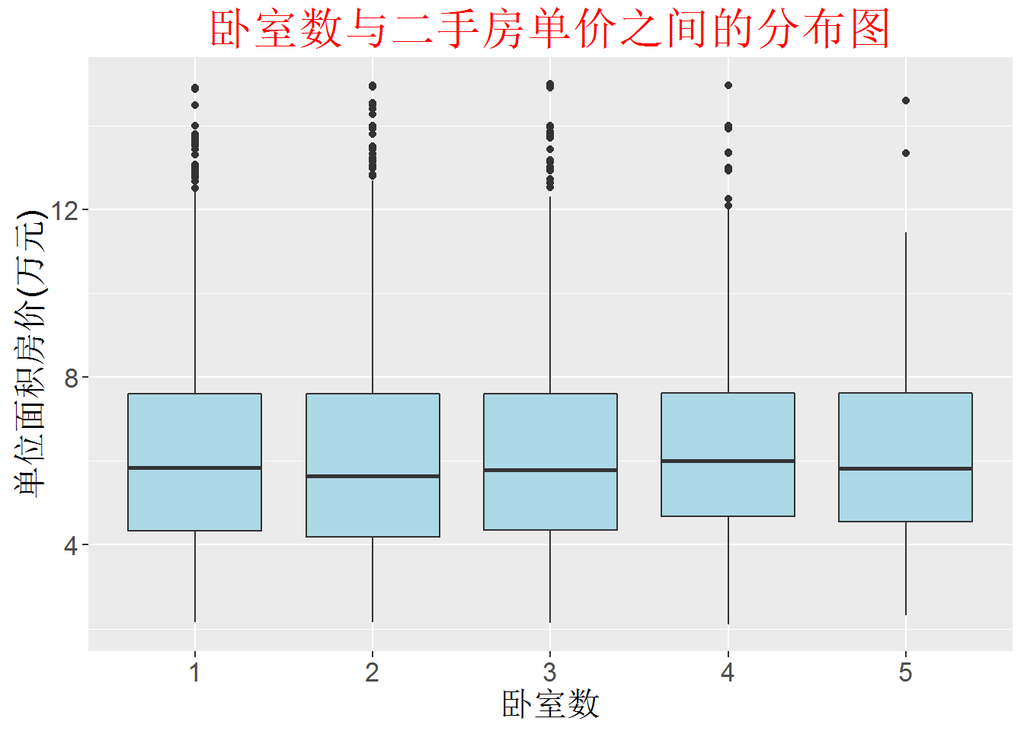

p3

```r
ggplot(dat, aes(x=bedrooms,y=price)) +
  geom_boxplot(fill='lightblue') +
  theme(axis.text.x=element_text(size=rel(1.5)), axis.text.y=element_text(size=rel(1.5)),
        axis.title.x=element_text(size=rel(1.5)), axis.title.y=element_text(size=rel(1.5)),
        plot.title=element_text(size=rel(2), color='red')) +
  labs(x='卧室数', y='单位面积房价(万元)',   title='卧室数与二手房单价之间的分布图')
```

由图可知，卧室数对整个二手房的单价影响不大。

### 厅数对房价的分组箱线图

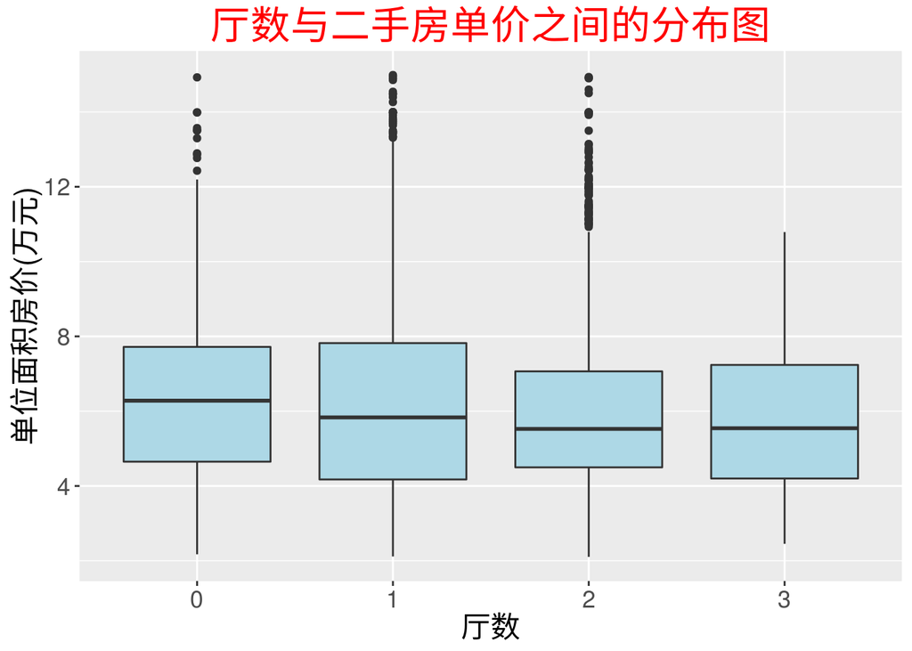

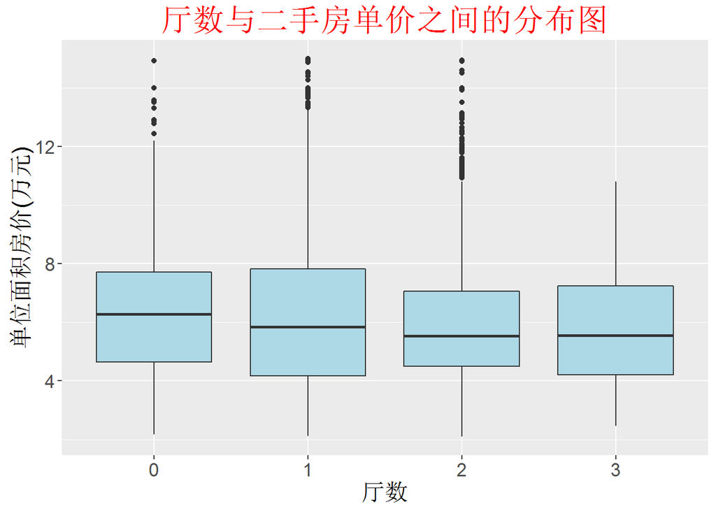

p4

```r
ggplot(dat, aes(x=halls,y=price)) +
  geom_boxplot(fill='lightblue') +
  theme(axis.text.x=element_text(size=rel(1.5)), axis.text.y=element_text(size=rel(1.5)),
        axis.title.x=element_text(size=rel(1.5)), axis.title.y=element_text(size=rel(1.5)),
        plot.title=element_text(size=rel(2), color='red')) +
  labs(x='厅数', y='单位面积房价(万元)', title='厅数与二手房单价之间的分布图')
```

由图可知，厅数越少，单位面积的房价越高

### 楼层对房价的分组箱线图

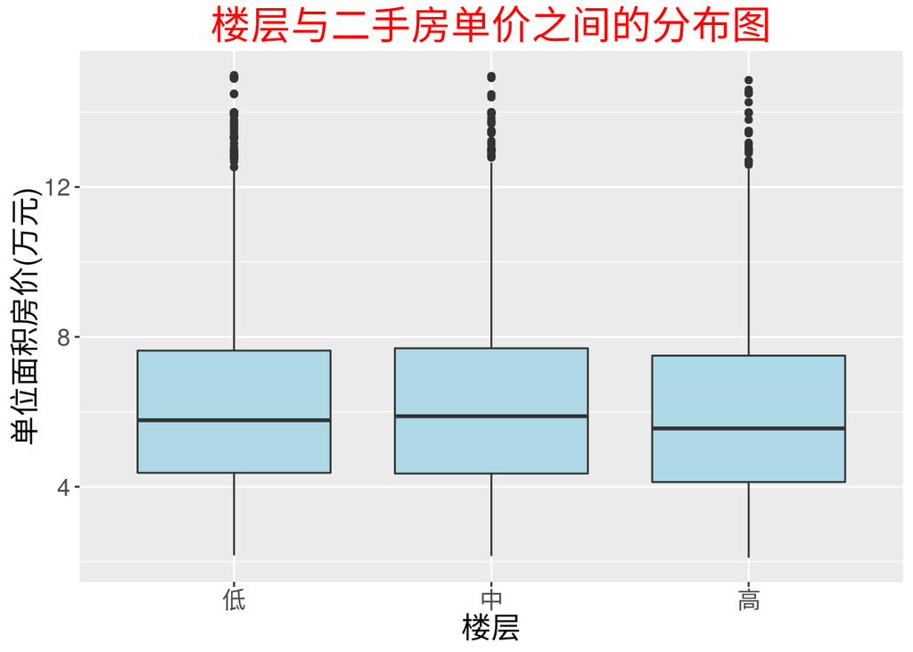

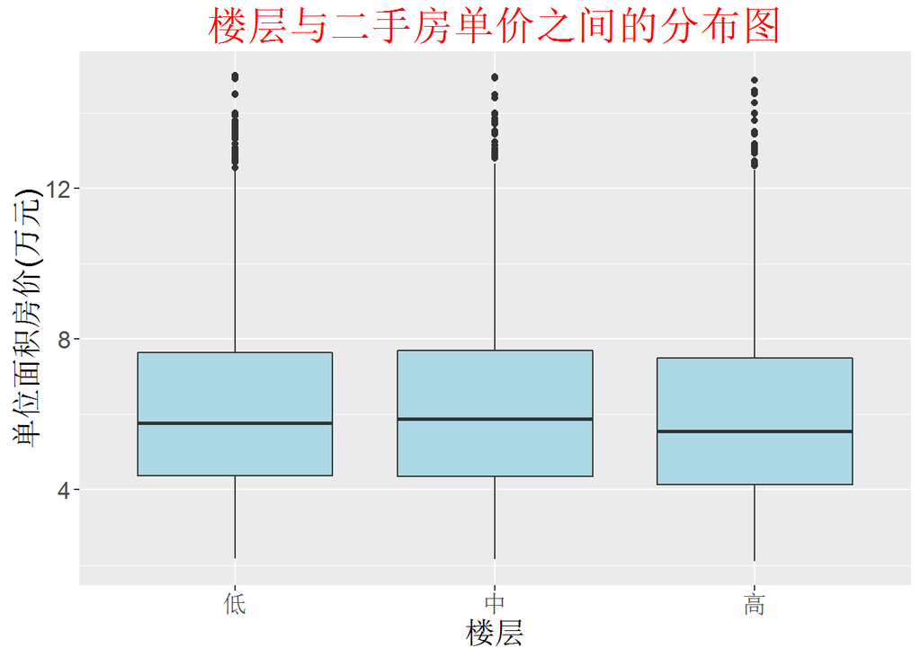

p5

```r
ggplot(dat, aes(x=floor,y=price)) +
  geom_boxplot(fill='lightblue') +
  theme(axis.text.x=element_text(size=rel(1.5)), axis.text.y=element_text(size=rel(1.5)),
        axis.title.x=element_text(size=rel(1.5)), axis.title.y=element_text(size=rel(1.5)),
        plot.title=element_text(size=rel(2), color='red')) +
  labs(x='楼层', y='单位面积房价(万元)', title='楼层与二手房单价之间的分布图') +
  scale_x_discrete(limits=c('低','中','高'))
```

不同楼层的单位面积房价差异并不明显

### 是否临近地铁对房价的分组箱线图

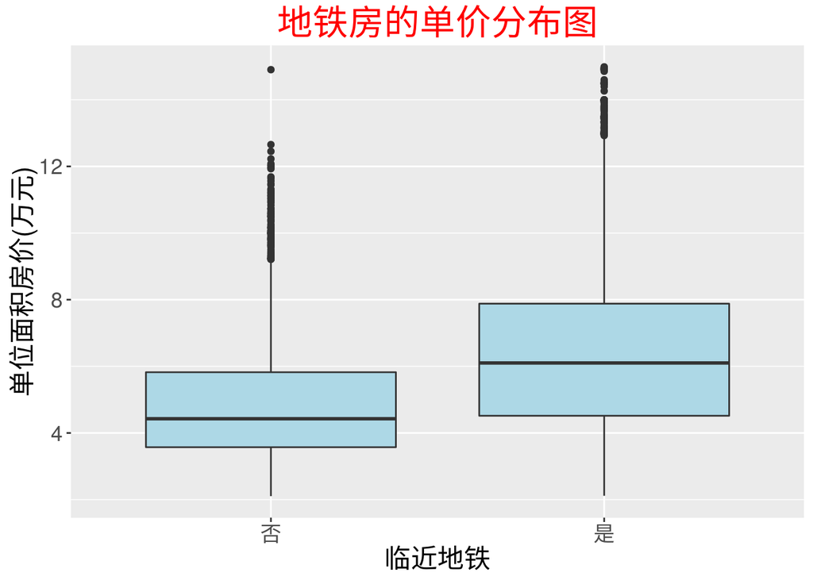

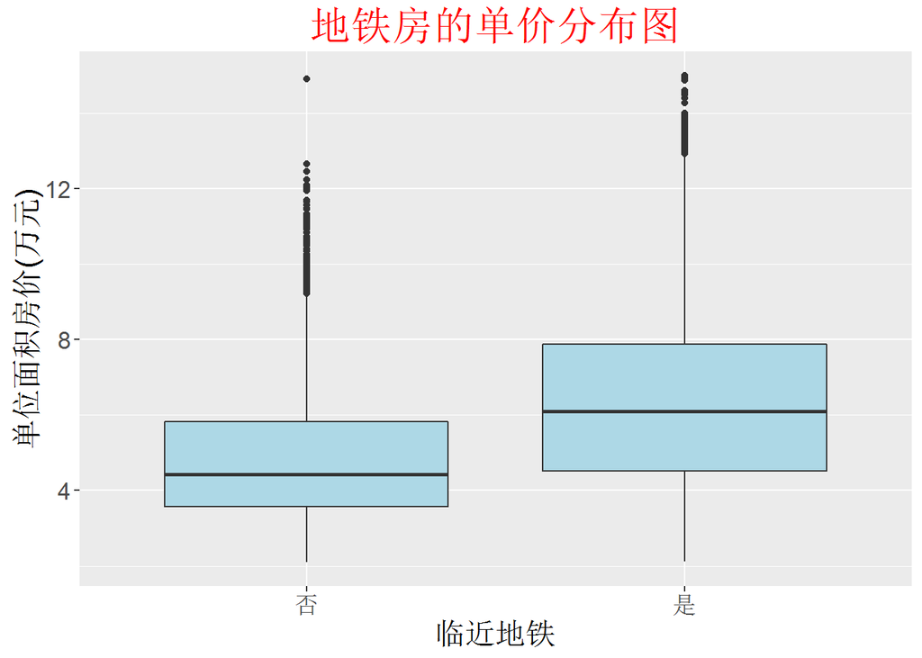

p6

```r
ggplot(dat, aes(x=subway,y=price)) +
  geom_boxplot(fill='lightblue') +
  theme(axis.text.x=element_text(size=rel(1.5)), axis.text.y=element_text(size=rel(1.5)),
        axis.title.x=element_text(size=rel(1.5)), axis.title.y=element_text(size=rel(1.5)),
        plot.title=element_text(size=rel(2), colour = 'red')) +
  labs(x='临近地铁', y='单位面积房价(万元)', title='地铁房的单价分布图') +
  scale_x_discrete(labels = c('否', '是'))
```

### 是否学区房对房价的分组箱线图

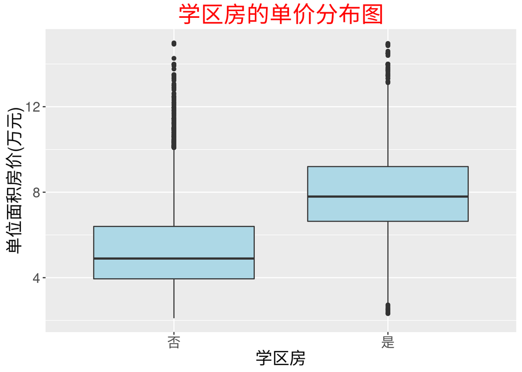

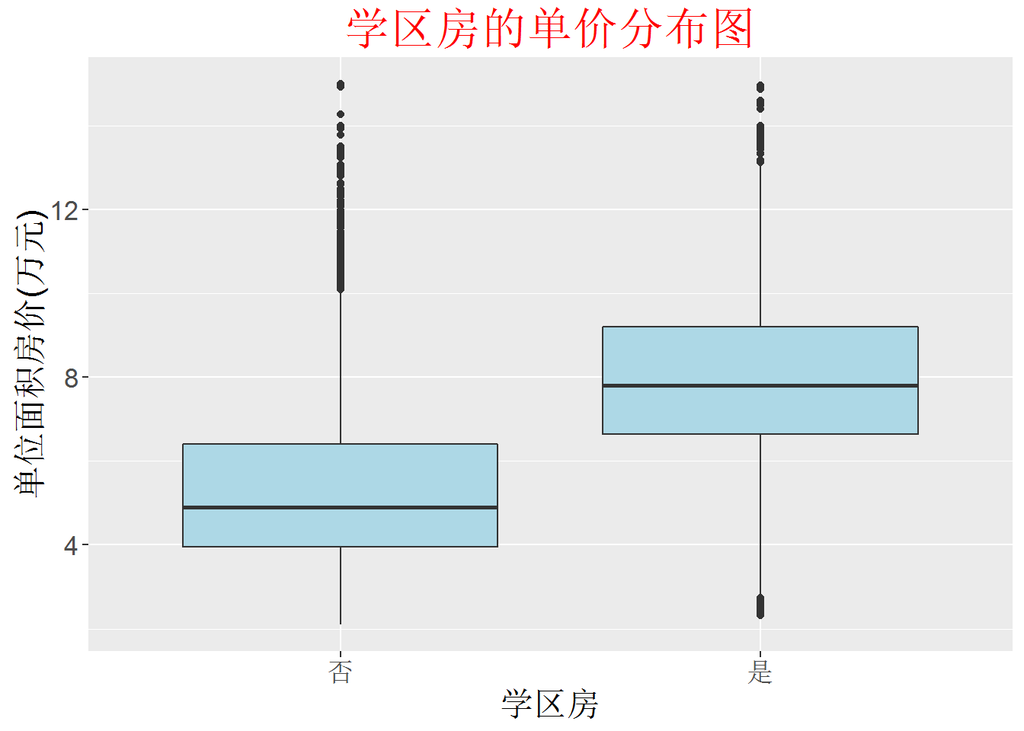

p7

```r
ggplot(dat, aes(x=school,y=price)) +
  geom_boxplot(fill='lightblue') +
  theme(axis.text.x=element_text(size=rel(1.5)), axis.text.y=element_text(size=rel(1.5)),
        axis.title.x=element_text(size=rel(1.5)), axis.title.y=element_text(size=rel(1.5)),
        plot.title=element_text(size=rel(2), colour = 'red')) +
  labs(x='学区房', y='单位面积房价(万元)', title='学区房的单价分布图') +
  scale_x_discrete(labels = c('否', '是'))
```

毋庸置疑，地铁房和学区房的单位面积房价都很高。

## 统计建模

### 模型建立

综合前面的描述统计分析，我们建立线性回归模型

```r
modeldata <- dat[,1:8]
dummvar <- model.matrix(price~.,modeldata)
modeldata <- cbind(dummvar[,-1],modeldata$price)
colnames(modeldata) <- c('CATE_dc','CATE_ft','CATE_hd','CATE_sjs','CATE_sc','bedrooms2',
                         'bedrooms3','bedrooms4','bedrooms5','halls1','halls2','halls3',
                         'AREA','floor_high','floor_medium','subway','school','price')
modeldata <- as.data.frame(modeldata)
lm1.sol <- lm(price~., data=modeldata)
summary(lm1.sol)
```

```
##
## Call:
## lm(formula = price ~ ., data = modeldata)
##
## Residuals:
##     Min      1Q  Median      3Q     Max
## -5.7891 -0.8696 -0.1430  0.7753  8.0368
##
## Coefficients:
##                Estimate Std. Error t value Pr(>|t|)
## (Intercept)   6.3259161  0.0701661  90.156  < 2e-16 ***
## CATE_dc      -2.3484458  0.0398010 -59.005  < 2e-16 ***
## CATE_ft      -0.2811257  0.0380570  -7.387 1.58e-13 ***
## CATE_hd      -2.4654227  0.0449268 -54.876  < 2e-16 ***
## CATE_sjs      1.2473939  0.0385689  32.342  < 2e-16 ***
## CATE_sc      -1.6400242  0.0389730 -42.081  < 2e-16 ***
## bedrooms2     0.0542040  0.0318197   1.703  0.08850 .
## bedrooms3     0.1918971  0.0418018   4.591 4.45e-06 ***
## bedrooms4     0.5218800  0.0800861   6.516 7.41e-11 ***
## bedrooms5     0.7514072  0.1581818   4.750 2.05e-06 ***
## halls1        0.1783148  0.0542266   3.288  0.00101 **
## halls2        0.7245641  0.0634363  11.422  < 2e-16 ***
## halls3        0.8406221  0.1709536   4.917 8.86e-07 ***
## AREA         -0.0068212  0.0004544 -15.010  < 2e-16 ***
## floor_high   -0.1999804  0.0275889  -7.249 4.40e-13 ***
## floor_medium -0.0497150  0.0274822  -1.809  0.07047 .
## subway        0.6907355  0.0306955  22.503  < 2e-16 ***
## school        1.1902485  0.0275494  43.204  < 2e-16 ***
## ---
## Signif. codes:  0 '***' 0.001 '**' 0.01 '*' 0.05 '.' 0.1 ' ' 1
##
## Residual standard error: 1.412 on 16124 degrees of freedom
## Multiple R-squared:  0.5972, Adjusted R-squared:  0.5968
## F-statistic:  1406 on 17 and 16124 DF,  p-value: < 2.2e-16
```

从回归诊断图来看，随着预测值得增大，残差的波动也随之增大，也即存在“异方差”。

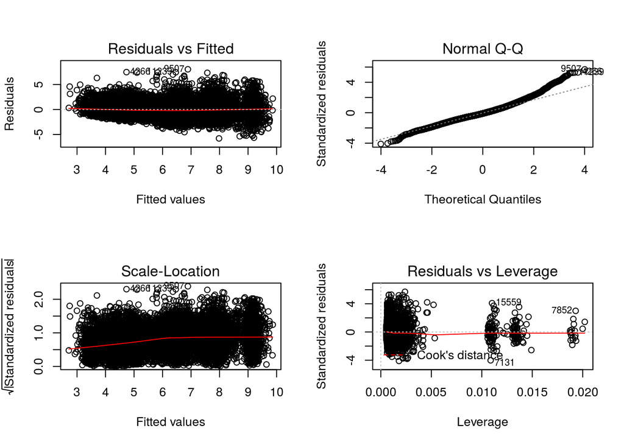

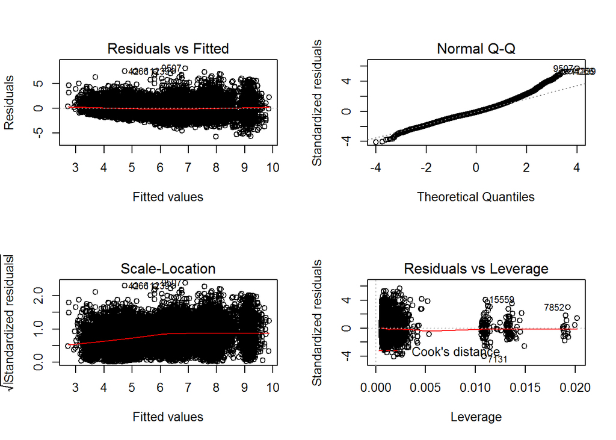

p8

```r
par(mfrow=c(2,2))
plot(lm1.sol)
plot(lm1.sol)
```